# STT 7140: Statistical Modeling for Environmental Data

Chapter 1: Introduction

Brandon M. Greenwell

Spring, 2018

## Introduction

- This is an Environmental Statistics course that covers basic statistical methodologies encountered in collecting and analyzing data from biological surveys and experiments.
  - **The methodology is more important than the application or examples!**
- Students in this class should have had at least one statistics course that covers the basic of probability, statistical thinking (e.g., variability), modeling, and inference.
- The notions of probability distributions (e.g., the **normal distribution**), hypothesis testing, test statistics, analysis of variance (ANOVA), $p$-values, and regression analysis should be familiar to students in this class.

## The topics we will cover include:

- Sampling design
- Linear, nonlinear, and linear mixed-effects models
- Generalized linear models (e.g., logistic regression)
- Decision trees and random forests
- Time series (e.g., ARIMA models)
- Spatial statistics (time pending)

## Sampling designs

- In order to test scientific hypotheses, one needs (good) data!
- Data can be obtained from *observational studies*—where one goes out and observes a population of interest, or from *experimental studies*—where one obtains data by running experiments.
- For observational data, in order to make valid statistical inferences, the data must be **representative of the population** from which it was obtained. This typically involves **randomly sampling**.
- There is a wide variety of sampling methods available. If one does not obtain a sample in a statistically valid fashion, then the data may not be of much use due to inadvertent selection biases.
- Additionally, a prudent choice of a sampling design may lead to **more efficient estimation** of population parameters, and **save time and money** in collecting data.

## Regression topics

- The basic idea of regression is to model how a a response variable, generically denoted $y$, depends on one or more “predictor” variables, generically denoted by $x$’s (e.g., $x_1, x_2, \dots, x_p$).
- Regression analysis allows us to model the relationships between the response and predictors.
- We can perform statistical tests to determine if particular models fit the data well.
- Models allow us to investigate if certain predictors influence, or are associated with, the response of interest.
- In other cases, we may just want to use the fitted regression model to make predictions (i.e., **predictive models**).
- A couple special cases of primary importance are polynomial models and models with indicator variables (i.e., **AN**alysis of **COVA**riance models).
- **Nonlinear** and **nonparametric** models are also important in many biological examples.

## Generalized linear models

- Traditional regression analysis assumes $y$ is continuous.
- Additionally, it is commonly assumed that $y$ is at least approximately normally distributed: $y \sim N\left(\mu, \sigma^2\right)$.
  - These assumptions are often not met in practice (e.g., when $y$ corresponds to a count or binary outcome).
- We shall cover the topic of **generalized linear models** (GLMs) which can accommodate response variables that are not continuous or normally distributed.
- The most commonly used GLM is **logistic regression** which is one way to model binary response variables.
- Another common GLM is **Poisson regression** which can be used to model counts (e.g., if $y$ is the number of zooplankton that survive after exposure to a toxin).

## Classification and regression trees

- All of the models previously discussed require us to know which predictors belong in the model, and how (i.e., they are all parametric in nature)!
- An alternative to GLMs and other additive models is **classification and regression trees** (CART).
- CART is a binary recursive partitioning method yielding a class of models called tree-based models.
- The CART method is attractive to many **exploratory environmental studies** due its many capabilities (e.g., handling variables of different types, automatic variable selection and ranking, missing value handling, use in ensembles, etc.).

## Time series

- Time series are very important in environmental studies.
- Any time data is collected sequentially over time (such as hourly temperature recordings), the resulting data form a time series.
- Time series analysis allows us to study both seasonal and overall trends in the data as well as correlation structure between successive measurements over time.

## Spatial statistics

- Environmental studies often involve data collected spatially, such as soil samples obtained in a large field.
- It is of interest in such studies to investigate if clusters exist, or if the data are spatially correlated.
- Spatial models can be used to model how correlations between measurements vary spatially.

## Statistical software

- R is free: https://www.r-project.org/.
- R is powerful and can perform most statistical methods of interest.
- R can produce very nice and high quality graphics fairly easily.
- R is extremely useful for running simple or complex simulations.
- R can be extended through add-on packages that implement state-of-the-art statistical methodologies. These packages are very easy to install, load, and use on your computer.
- All the cool people are using R: https://github.com/bgreenwell.
- **RStudio** makes R easier to use. It includes a code editor, debugging tools, and visualization tools: https://www.rstudio.com/.
- Free tutorial: https://www.datacamp.com/courses/free-introduction-to-r.
- **For your first homework assignment, complete the above tutorial and read through chapter 1!**

## DOE: terminology

**Example:** An experiment is carried out to see how genotype and the amount of phosphorus affect plant growth. The biomass of the plant is the measured response. Three genotypes and two phosphorus levels (low and high) were used in the experiment. There were 10 plants grown at each experimental combination.

- This is an example of a $3 \times 2$ **factorial experiment**.
- **Response variable:** The response (or dependent) variable in this example is the biomass of the plant.
- **Factors:** The independent variables which *may* influence the response variable (genotype and phosphorus in this example).
- **Levels:** The individual levels of each factor. For example, genotype has three levels and phosphorus has two.
- **Treatment:** A combination of factor levels.
- A *full* factorial experiment is an experiment whose design consists of two or more factors, and whose experimental units take on all possible combinations of levels across all factors.
- **Question:** For the above plant growth example, write out all of the possible treatment combinations. Is this a full factorial experiment?
- **Replicates:** The number of experimental units (plants in this example) per treatment.
- **Balanced design:** This occurs when each treatment combination uses the same number of replicates.
- **Question:** How many replicates per treatment are used in the plant growth example? Is this a balanced design?

## DOE: basics

- In a *designed experiment*, researchers control the allocation of treatments to the experimental units.
- The **experimental unit** is the smallest unit to which treatment combinations are applied (e.g., people, animals, beakers of liquids, plots of land, etc.).
- The **observational unit** (or **sampling unit**) is the unit upon which measurements are taken.
- Sometimes the experimental and observational units are one in the same, and other times they differ.
- For example, a beaker of water may contain several organisms and the objective of the experiment is to expose the organisms to a particular chemical. If the chemical is added to the water, then the experimental unit is the beaker. If responses are recorded for individual organisms within the beaker, then the organisms are the observational units.

## DOE: basics

- In *observational designs*, the researchers **do not** have control over the allocation of treatments, but instead observe a population of interest.
- The **population** is the collection of all possible **sampling units** of interest.
- When identifying the population, the investigator must determine to which group will the conclusions of the statistical inference be applied.
- One advantage of performing an experiment as opposed to an observational study is that it is easier to determine **cause and effect** with an experiment via the use of **randomization**.
- In an observational study, if we note an association (or correlation) between two variables, it may not be possible to say one effect causes the other—**correlation does not imply causation!**
- For example, does second-hand smoke cause cancer in humans?
- There may exist a positive association between these two variables, but there are many other variables that one may not be able to control that could also have an impact on lung cancer rates.

## DOE: basics

- If the goal of an experiment is to study the effect of some treatment, say an environmental toxin, on a population of interest, then good experimental design requires the elimination of all other variables that may effect the outcome to the greatest extent possible.
- **You can NEVER prove cause and effect!**
- For example, if we want to *study the effect of a single toxin on a particular organism*, then we would want to control for (to the greatest extent possible) the effect of any other variables on the organism (e.g., temperature, lab conditions, lab technicians, solution preparations, etc.).
- If an effect is discovered when analyzing the data, the experimenter would like to be able to attribute that effect to the toxin. However, this will not be possible if there are other variables that were not controlled that could have caused the effect.
- This is sometimes referred to as **local control**.
- Experimental units should be as similar to each other as possible in order to obtain local control. If there is a high degree of variability among the experimental units, then it may be difficult to detect a true effect.

## DOE: blinding

- Another aspect of local control is the notion of **blinding**.
- There are many examples of studies whose results came out wrong because the experimenter had reason to believe the experiment would come out in a particular way even before the experiment was even conducted (e.g., people tend to find evidence that supports their views while discarding or ignoring evidence that does not)—while this typically occurs on a subconscious level, scientists are not exempt from this sort of bias.
- For this reason, it is important for investigators to protect their research by **blinding or masking**.
- For instance, if one wants to study the effect of an environmental toxin on an organism in an experiment using different levels of toxin exposure, then the investigator should not know which experimental units received which treatment.
- In a **single-blind study**, the subjects do not know which treatment they are receiving—more relevant to human subject research (e.g., clinical trials).
- In a **double-blind study**, neither the subjects nor the experimenter knows which subjects are receiving which treatments.

## DOE: controls

- Another fundamental aspect of DOE is that of a **control group**.
- If a study of the effect of a toxin on an organism shows an effect, how can the experimenter know the effect is more than what could occur by chance alone?
- A control group in this situation may be a group of organisms that are as similar as possible to the organisms that are exposed to the toxin except the control group is not subject to exposure.
- Therefore, if a difference is observed between the treatment group and control group that is *too big to have occurred by chance alone* (as measured by $p$-values typically), then it may be reasonable to attribute the difference to the toxin.
- In studies of anti-depressants, the control group is often a group of subjects taking a placebo.
- **It is important that these types of studies be double-blind!**

## DOE: randomization

- There will always be some intrinsic variability between sampling units.
- For instance, no two human subjects are exactly the same (not even identical twins), even after considering factors such as age, size, etc.
- In order to balance out uncontrolled systematic effects in an experiment, units are assigned to treatment combinations using **randomization**—the process of assigning treatments to experimental units at **random**.
- If there exist systematic effects that we have not (or could not) control for, then the use of randomization will hopefully wash out differences between treatments that are not due to the treatments themselves.
- Suppose in the fish toxicity example that some fish have a genetic predisposition to be immune to the harmful effects of the toxin and that the experimenters are unaware of this genetic effect. If the fish are randomized to different treatments based on varying doses of the toxin, then randomization will help make it possible with a high degree of probability that the fish with and without this genetic predisposition will balance out between the treatments.
- **Non-random allocation of treatment to experimental units puts the experiment at risk of bias, even when it is unintentional!**

## Single factor ANOVA

- In some experiments, there may only be a single factor of interest, say, the dose of a toxin.
- The statistical analysis for a single factor design is usually based on an ANOVA $F$-test.
- The levels of the factor in this example would be the different dose levels of interest and the experimental units (e.g., organisms) would be randomly assigned to the various levels of the factor.
- If an equal number of units are assigned to each level, then the design is said to be balanced.
- If $y$ represents the variable of interest that is measured, then one may be interested in the mean values of $y$ at each level of the factor.
- **Question:** How do we estimate these means?

## Single factor ANOVA

- It is often of interest to see if the mean response differs among the different levels of the factor.
- **Spoiler alert:** All null hypotheses are technically false!
- If the factor only has two levels, then a two-sample $t$-test can be be used (provided certain assumptions are met).
- **Questions:** What are the assumptions of the classic two-sample $t$-test?
- If the factor has more than two levels, then the general statistical procedure is to partition the overall variability in the response into two parts: (i) *between treatment variation* and (ii) *within treatment variation*. (Hence, the name ANOVA.)

## Single factor ANOVA

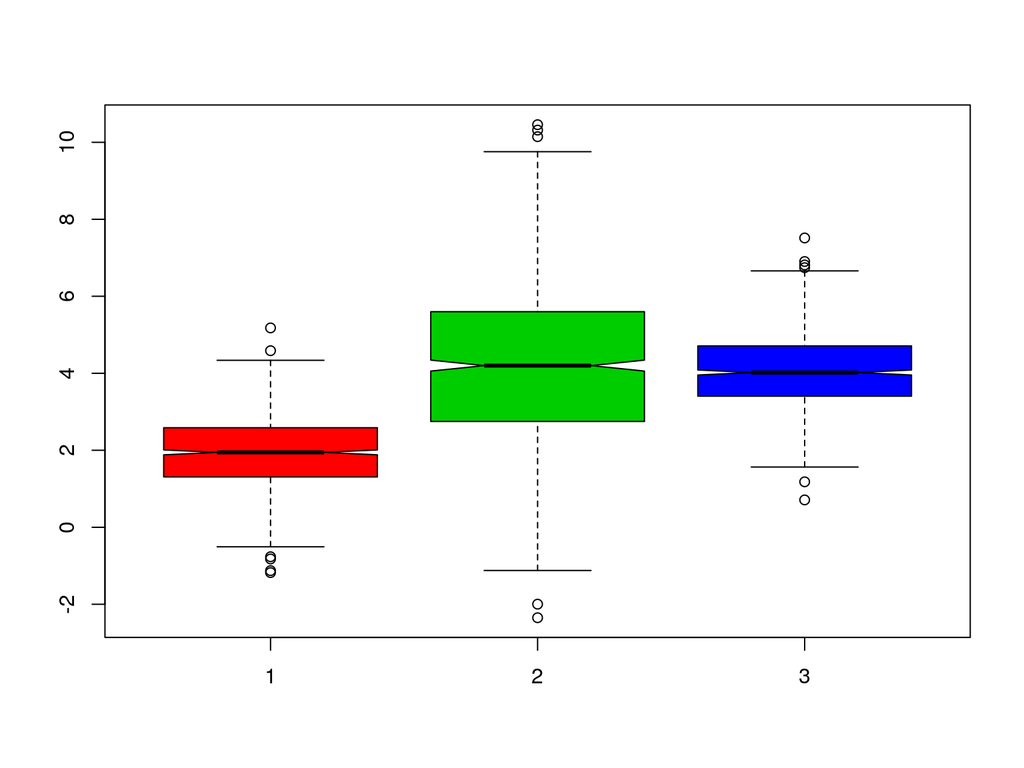

```r
# Simulated data from three normal distributions with different means and
# standard deviations
set.seed(101)
x1 <- rnorm(1000, mean = 2, sd = 1)
x2 <- rnorm(1000, mean = 4.2, sd = 2)
x3 <- rnorm(1000, mean = 4, sd = 1)
boxplot(x1, x2, x3, col = 2:4, notch = TRUE)
```

## Single factor ANOVA

- The classical inference procedure is to do an $F$-test, where the $F$-test statistic is the ratio of the estimated variance between levels of the factor and the estimated variance within each level of the factor: $F = \sigma_{between} ^ 2 / \sigma_{within} ^ 2$
- The null hypothesis, denoted $H_0$, is that the means across all levels of the factor are equal. (Write this out!)
- If $H_0$ is true, then $F$ follows an $F$-distribution.
- If $H_0$ is true, then $F$ tends to take a value near one on average.
- If $H_0$ is false, then $F$ tends to be larger than one.
- A $p$-value can be computed to access how likely it is to observe a value of $F$ when $H_0$ is true.
- As with most hypothesis testing procedures, a small $p$-value (say $p < 0.05$) is evidence against $H_0$.

## Single factor ANOVA

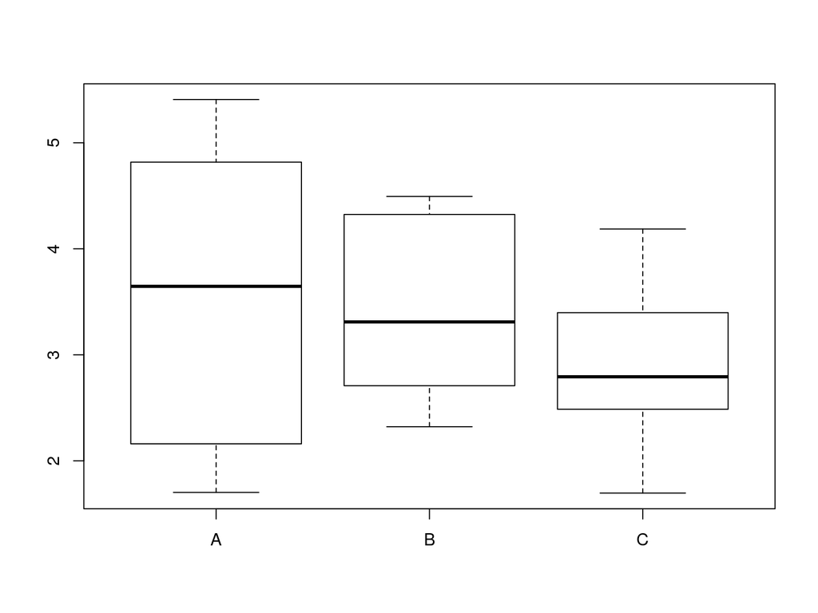

```r
# Simulated data from two normal distributions with different means but
# equal standard deviations (n = 30)
set.seed(0958)
n <- 10
y1 <- rnorm(n, mean = 3, sd = 1)
y2 <- rnorm(n, mean = 3.01, sd = 1)
y3 <- rnorm(n, mean = 2.99, sd = 1)
d <- data.frame(y = c(y1, y2, y3), x = rep(LETTERS[1:3], each = n))
boxplot(y ~ x, data = d)
```

```r
summary(aov(y ~ x, data = d))
```

```
##             Df Sum Sq Mean Sq F value Pr(>F)
## x            2  2.087   1.044   0.989  0.385
## Residuals   27 28.492   1.055
```

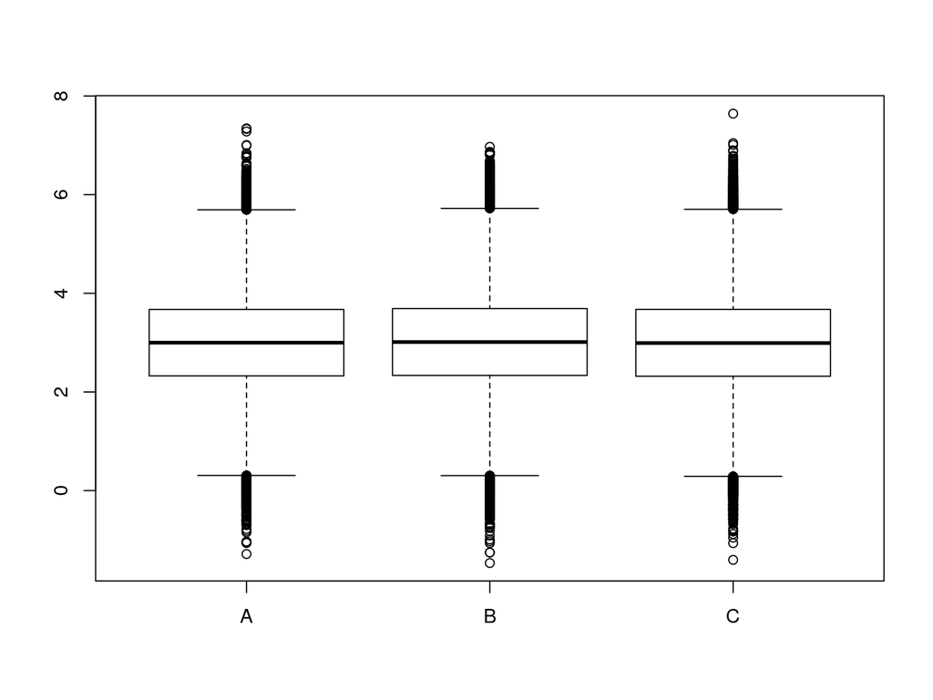

```r
# Simulated data from two normal distributions with different means but
# equal standard deviations (n = 100000)
set.seed(0978)
n <- 100000
y1 <- rnorm(n, mean = 3, sd = 1)
y2 <- rnorm(n, mean = 3.01, sd = 1)
y3 <- rnorm(n, mean = 2.99, sd = 1)
d <- data.frame(y = c(y1, y2, y3), x = rep(LETTERS[1:3], each = n))
boxplot(y ~ x, data = d)
```

```r
summary(aov(y ~ x, data = d))
```

```
##                Df Sum Sq Mean Sq F value   Pr(>F)
## x           2e+00     19   9.555   9.499 7.49e-05 ***
## Residuals   3e+05 301745   1.006
## ---
## Signif. codes:  0 '***' 0.001 '**' 0.01 '*' 0.05 '.' 0.1 ' ' 1
```

## Single factor ANOVA: real example

```r
# Data from an observationsl study on the liver PCB concentration in Black
# Guillemot birds in Canada at three different sites.
site <- c('ref', 'ref', 'ref', 'ref', 'ref', 'ref', 'ref', 'ref', 'ref', 'ref',
          'ref', 'island', 'island', 'island', 'island', 'island', 'island',
          'island', 'island', 'island', 'island', 'beach', 'beach', 'beach',
          'beach', 'beach', 'beach', 'beach', 'beach', 'beach', 'beach',
          'beach')
lipid <- c(325, 281, 412, 621, 424, 768, 904, 678, 908, 2234, 1819, 1315, 1315,
           1212, 1999, 3108, 3011, 3804, 4450, 3779, 5301, 6564, 10460, 10650,
           17230, 15540, 18920, 30970, 51960, 92130, 139190, 152100)
pcb <- data.frame(site, lipid)
```

## Single factor ANOVA

```r
# View the data
# install.packages("DT")
DT::datatable(pcb)
```

|  | site | lipid |
| --- | --- | --- |
| 1 | ref | 325 |
| 2 | ref | 281 |
| 3 | ref | 412 |
| 4 | ref | 621 |
| 5 | ref | 424 |
| 6 | ref | 768 |
| 7 | ref | 904 |
| 8 | ref | 678 |
| 9 | ref | 908 |
| 10 | ref | 2234 |

[output cut: 22 more lines]

## Single factor ANOVA

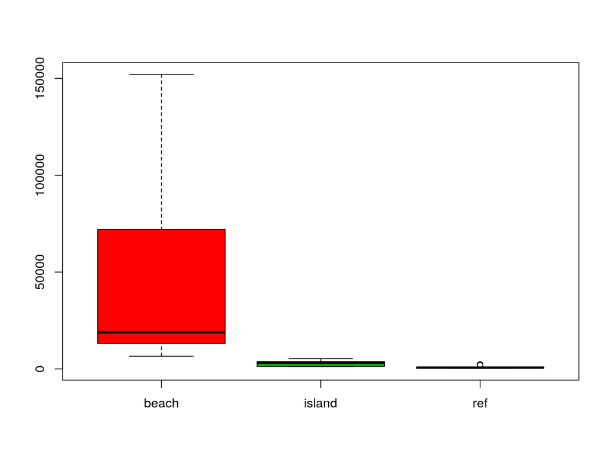

```r
# Construct a boxplot of lipid at each site
boxplot(lipid ~ site, data = pcb, col = 2:4)
```

## Single factor ANOVA

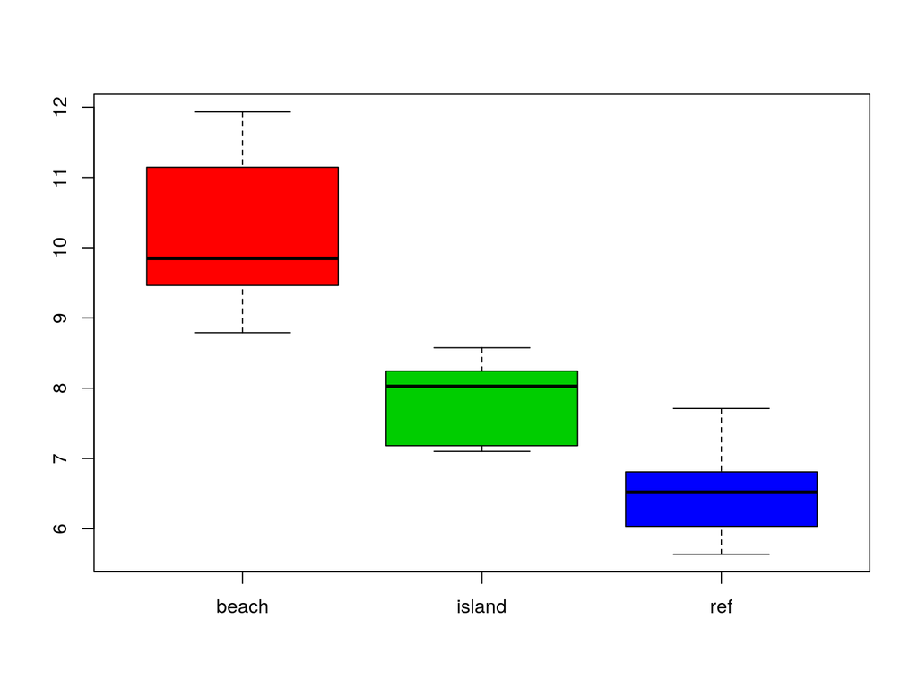

```r
# Construct a boxplot of log(lipid) at each site
boxplot(log(lipid) ~ site, data = pcb, col = 2:4)
```

## Single factor ANOVA

```r
# Compute the mean log(lipid) at each site
tapply(log(lipid), INDEX = site, FUN = mean)
```

```
##     beach    island       ref
## 10.270672  7.857271  6.538443
```

## Single factor ANOVA

```r
# Conduct a one-way ANOVA
pcb_aov <- aov(log(lipid) ~ site, data = pcb)
summary(pcb_aov)  # look at summary of results
```

```
##             Df Sum Sq Mean Sq F value  Pr(>F)
## site         2  78.67   39.34   59.84 5.1e-11 ***
## Residuals   29  19.06    0.66
## ---
## Signif. codes:  0 '***' 0.001 '**' 0.01 '*' 0.05 '.' 0.1 ' ' 1
```

## Interpretting $p$-values

Here are some **rough** guidelines for interpreting $p$-values which can be used in any testing scenario (not just for testing hypotheses about the mean). Let $p$ denote the $p$-value of a test:

- $p \le 0.01$ can be interpetted as very strong evidence against $H_0$.
- $0.01 < p \le 0.05$ can be interpetted as strong evidence against $H_0$.
- $0.05 < p \le 0.10$ can be interpetted as moderate evidence against $H_0$.
- $0.10 \le p < 0.20$ can be interpetted as fairly weak evidence against $H_0$.
- $p > 0.20$ can be interpetted as no evidence against $H_0$.

## Single factor ANOVA

```r
# Look at pairwise comparisons (Tukey's method)
TukeyHSD(pcb_aov)
```

```
##   Tukey multiple comparisons of means
##     95% family-wise confidence level
##
## Fit: aov(formula = log(lipid) ~ site, data = pcb)
##
## $site
##                   diff       lwr       upr     p adj
## island-beach -2.413401 -3.288282 -1.538520 0.0000005
## ref-beach    -3.732229 -4.586025 -2.878432 0.0000000
## ref-island   -1.318828 -2.193709 -0.443947 0.0023631
```

## Single factor ANOVA

```r
# Look at pairwise comparisons (alternative methods)
pairwise.t.test(log(lipid), g = site)
```

```
##
##  Pairwise comparisons using t tests with pooled SD
##
## data:  log(lipid) and site
##
##        beach   island
## island 3.5e-07 -
## ref    3.4e-11 0.00084
##
## P value adjustment method: holm
```

```r
p.adjust.methods
```

```
## [1] "holm"       "hochberg"   "hommel"     "bonferroni" "BH"
## [6] "BY"         "fdr"        "none"
```

## Multifactor studies

- In some experiments, interest lies in more than one factor (e.g., the plant biomass example).
- In a two-factor ANOVA (or two-way ANOVA), a treatment consists of a level of one factor and a level of the other factor.
- For example, the experimental unit may be a plant and the two factors could be type of fertilizer and amount of water.
- For a two-factor ANOVA, the overall variability in the response can be partitioned into four parts: variability due to the first factor, the second factor, interactions between the two factors, and a within treatment variability.
- Again, the classic inference procedure is based on an $F$-test.
- Typically one would first test to see if there is a significant **interaction effect** (visualizing the raw data is useful here!).
- If the interaction is not significant, then it makes sense to test if there are **main effects** for the two factors.

## Multifactor studies

```r
# A study was conducted to examine if mean corn yield, measured in metric tons,
# depends on levels of manure and nitrogen-based fertilizer

# Load the data from the web
url <- paste0("https://onlinecourses.science.psu.edu/stat500/sites/",
              "onlinecourses.science.psu.edu.stat500/files/lesson11/",
              "corn_yield.txt")
corn <- read.table(url, header = TRUE)  # load the data into R
print(corn)  # view all of the observations; print function NOT required
```

```
##    Fert Manure Yield
## 1  High   High  13.7
## 2  High   High  16.8
## 3  High   High  14.9
## 4  High   High  17.6
## 5  High   High  16.5
## 6   Low   High  17.4
## 7   Low   High  13.5
## 8   Low   High  15.1
## 9   Low   High  15.4
## 10  Low   High  13.2
## 11 High    Low  16.0
## 12 High    Low  16.1
## 13 High    Low  13.0
## 14 High    Low  16.7
## 15 High    Low  13.2
## 16  Low    Low  13.4
## 17  Low    Low  11.6
## 18  Low    Low  14.7
## 19  Low    Low   9.7
## 20  Low    Low  11.9
```

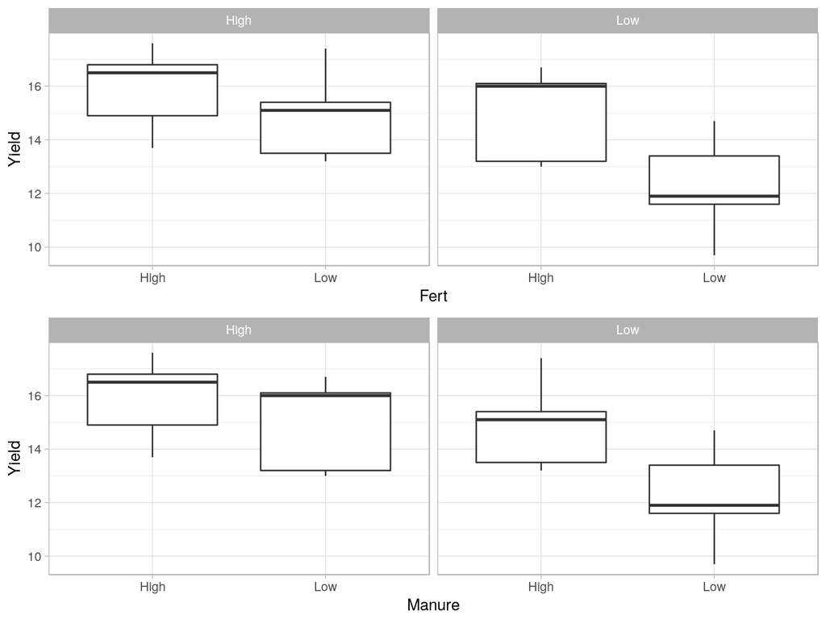

```r
# Boxplots
library(ggplot2)
p1 <- ggplot(corn, aes(x = Fert, y = Yield)) +
  geom_boxplot() +
  facet_wrap( ~ Manure) +
  theme_light()
p2 <- ggplot(corn, aes(x = Manure, y = Yield)) +
  geom_boxplot() +
  facet_wrap( ~ Fert) +
  theme_light()
gridExtra::grid.arrange(p1, p2)
```

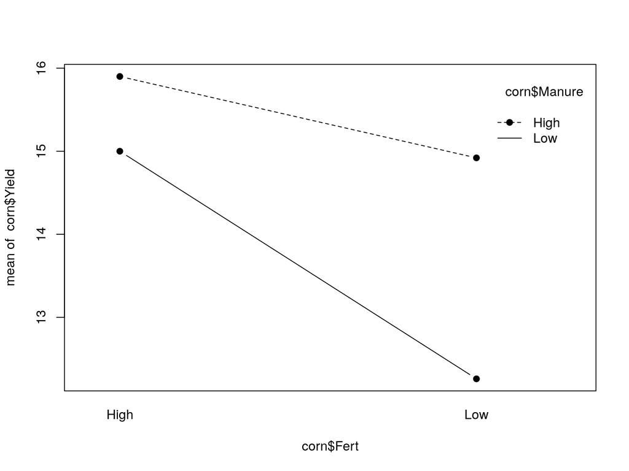

```r
# Classic two-way interaction plot
interaction.plot(x.factor = corn$Fert, trace.factor = corn$Manure,
                 response = corn$Yield, type = "b", pch = 19)
```

```r
# Classic two-way ANOVA (with an interaction effect)
corn_aov <- aov(Yield ~ Fert * Manure, data = corn)
summary(corn_aov)
```

```
##             Df Sum Sq Mean Sq F value Pr(>F)
## Fert         1  17.30  17.298   5.766 0.0288 *
## Manure       1  15.84  15.842   5.281 0.0354 *
## Fert:Manure  1   3.87   3.872   1.291 0.2727
## Residuals   16  48.00   3.000
## ---
## Signif. codes:  0 '***' 0.001 '**' 0.01 '*' 0.05 '.' 0.1 ' ' 1
```

```r
# Refit the model without the interaction term
corn_aov <- update(corn_aov, Yield ~ Fert + Manure)
summary(corn_aov)
```

```
##             Df Sum Sq Mean Sq F value Pr(>F)
## Fert         1  17.30  17.298   5.669 0.0292 *
## Manure       1  15.84  15.842   5.192 0.0359 *
## Residuals   17  51.87   3.051
## ---
## Signif. codes:  0 '***' 0.001 '**' 0.01 '*' 0.05 '.' 0.1 ' ' 1
```

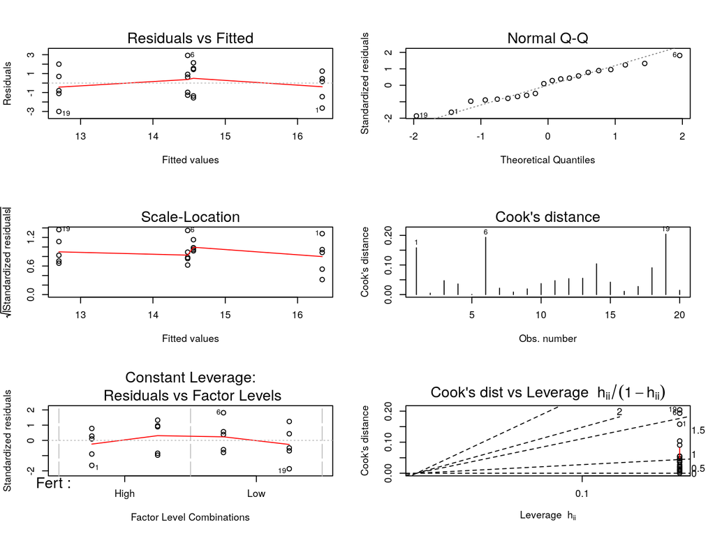

```r
# Various diagnostic plots
par(mfrow = c(3, 2))
plot(corn_aov, which = 1:6)
```

```r
# Pairwise comparisons
TukeyHSD(corn_aov, conf.level = 0.95)
```

```
##   Tukey multiple comparisons of means
##     95% family-wise confidence level
##
## Fit: aov(formula = Yield ~ Fert + Manure, data = corn)
##
## $Fert
##           diff       lwr        upr     p adj
## Low-High -1.86 -3.508168 -0.2118319 0.0292283
##
## $Manure
##           diff       lwr        upr     p adj
## Low-High -1.78 -3.428168 -0.1318319 0.0358875
```

## Blocking

- In some studies, we may only be interested in one factor—but other factors may explain much of the variability in the outcome.
- We may want to include these other factors to block out variation that is not of primary interest (i.e., to reduce the variance in what we are estimating).
- Often, blocks need to be included in the model to appropriately control for certain variables.
- **Blocking is used to “remove” the effect of nuisance factors!**
- For example, often an experiment is conducted by taking **repeated measurements** on the same person, animal, or plant, etc.
- **Question:** Can you think of a simple statistical test that makes use of blocking?
- Taking repeated measurements on an experimental unit can help factor out variability between units so that a more focused analysis can be performed on the experimental condition of interest, like a particular treatment.
- In an experiment on plants, many plants may exist in the same plot, so the plot can act as a **block**.
- An important point here is that **outcomes within a block will tend to be correlated with each other** and this correlation must be taken into consideration for the conclusions to be valid.

## Random effects

- Often, the blocking factor is a **random effect** (i.e., where the levels of the factor may be considered as random instead of fixed).
- Consider an experiment to study plant growth under both a control and an experimental treatment (e.g., a fertilizer).
- The treatment (control versus fertilizer) is a fixed effect with two levels.
- The experiment will use several plants, half of which are randomized to the control group and the other half to the fertilizer group.
- Each plant will be repeatedly measured over time. Here, we can consider the plants as a random sample from the population of plants (i.e., plant would be considered a random effect).

## Random effects

```r
# Install required packages
# install.packages("BHH2", "lme4", "lmerTest")

# Load the penicillin yield example data set
data(penicillin.data, package = "BHH2")
print(penicillin.data)  # print first few rows for inspection
```

```
##    blend run treat yield
## 1     B1   1     A    89
## 2     B2   4     A    84
## 3     B3   2     A    81
## 4     B4   1     A    87
## 5     B5   3     A    79
## 6     B1   3     B    88
## 7     B2   2     B    77
## 8     B3   1     B    87
## 9     B4   3     B    92
## 10    B5   4     B    81
## 11    B1   2     C    97
## 12    B2   3     C    92
## 13    B3   4     C    87
## 14    B4   2     C    89
## 15    B5   1     C    80
## 16    B1   4     D    94
## 17    B2   1     D    79
## 18    B3   3     D    85
## 19    B4   4     D    84
## 20    B5   2     D    88
```

```r
# Cross tabulation
xtabs(yield ~ blend + treat, data = penicillin.data)
```

```
##      treat
## blend  A  B  C  D
##    B1 89 88 97 94
##    B2 84 77 92 79
##    B3 81 87 87 85
##    B4 87 92 89 84
##    B5 79 81 80 88
```

```r
# Load required packages
library(lmerTest)  # for fitting mixed-effects models
library(nlme)  # for fitting mixed-effects models
```

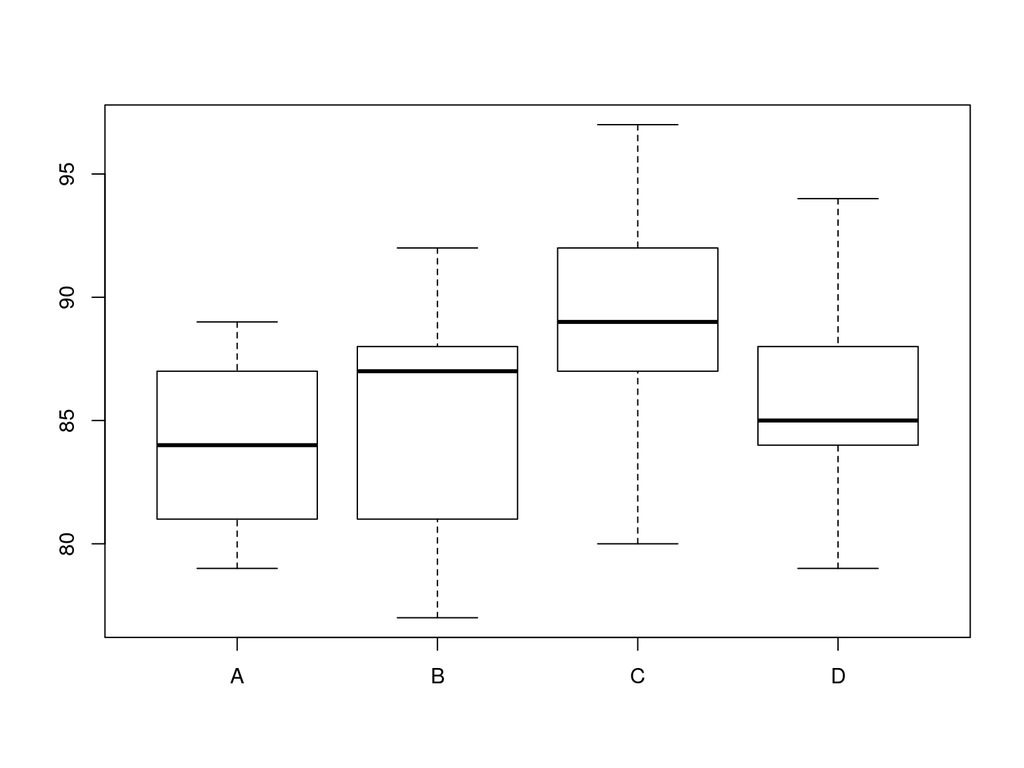

```r
# Boxplot
boxplot(yield ~ treat, data = penicillin.data)
```

```r
# Mixed-effects model
fit1 <- lmer(yield ~ treat + (1 | blend), data = penicillin.data)
# fit2 <- lme(yield ~ treat, random = ~ 1 | blend, data = penicillin.data)

# Print model summary
summary(fit1)
```

```
## Linear mixed model fit by REML t-tests use Satterthwaite approximations
##   to degrees of freedom [lmerMod]
## Formula: yield ~ treat + (1 | blend)
##    Data: penicillin.data
##
## REML criterion at convergence: 103.8
##
## Scaled residuals:
##     Min      1Q  Median      3Q     Max
## -1.4152 -0.5017 -0.1644  0.6830  1.2836
##
## Random effects:
##  Groups   Name        Variance Std.Dev.
##  blend    (Intercept) 11.79    3.434
##  Residual             18.83    4.340
## Number of obs: 20, groups:  blend, 5
##
## Fixed effects:
##             Estimate Std. Error     df t value Pr(>|t|)
## (Intercept)   84.000      2.475 11.075  33.941 1.51e-12 ***
## treatB         1.000      2.745 12.000   0.364   0.7219
## treatC         5.000      2.745 12.000   1.822   0.0935 .
## treatD         2.000      2.745 12.000   0.729   0.4802
## ---
## Signif. codes:  0 '***' 0.001 '**' 0.01 '*' 0.05 '.' 0.1 ' ' 1
##
## Correlation of Fixed Effects:
##        (Intr) treatB treatC
## treatB -0.555
## treatC -0.555  0.500
## treatD -0.555  0.500  0.500
```

```r
anova(fit1)
```

```
## Analysis of Variance Table of type III  with  Satterthwaite
## approximation for degrees of freedom
##       Sum Sq Mean Sq NumDF DenDF F.value Pr(>F)
## treat     70  23.333     3    12  1.2389 0.3387
```

```r
# Print model summary
# summary(fit2)
# anova(fit2)  # test for overall significance of treatment effect
```

## Simulations

- Classical statistical inference procedures were developed before the age of high speed computing.
- New procedures can take advantage of new computing power.
- Thanks to the power of computing, we can use simulations to evaluate how certain statistical procedures perform.
- The idea of simulations is to have the computer generate a set of pseudo data or simulated data.

## Bootstrap simulation example

````
```r
# install.packages("pbkrtest")
library(pbkrtest)
fit1 <- lmer(yield ~ treat + (1 | blend), data = penicillin.data)
fit2 <- lmer(yield ~ (1 | blend), data = penicillin.data)

# Classic likelihood ratio (LR) test
anova(fit1, fit2)
```

```
## refitting model(s) with ML (instead of REML)
```

```
## Data: penicillin.data
## Models:
## ..1: yield ~ (1 | blend)
## object: yield ~ treat + (1 | blend)
##        Df    AIC    BIC  logLik deviance  Chisq Chi Df Pr(>Chisq)
## ..1     3 127.33 130.31 -60.662   121.33
## object  6 129.28 135.25 -58.639   117.28 4.0474      3     0.2564
```

```r
# More accurate test based on simulation (in this case, a parametric
# bootstrap)
pb <- PBmodcomp(largeModel = fit1, smallModel = fit2, nsim = 1000, seed = 1)
summary(pb)  # also performs and prints other test results for comparison
```

```
## Parametric bootstrap test; time: 12.47 sec; samples: 1000 extremes: 323;
## large : yield ~ treat + (1 | blend)
## small : yield ~ (1 | blend)
##            stat     df  ddf p.value
## PBtest   4.1372              0.3237
## Gamma    4.1372              0.3198
## Bartlett 3.5145 3.0000       0.3189
## F        1.3791 3.0000 2.79  0.4069
## LRT      4.1372 3.0000       0.2470
```
````

## Nonparametric density estimation

- If $X$ denotes a continuous random variable (e.g., skull length), we would like to know its density function $f\left(x\right)$ but in practice the density is unknown.
- Often we may use a normal density to approximate $f\left(x\right)$, but this is not a good idea if the data is clearly non-normal.
- A histogram provides a crude approximation to the density function $f\left(x\right)$.

The idea of nonparametric density estimation is to obtain a better (smooth) approximation to $f\left(x\right)$.

- The most popular method of nonparametric density estimation is **kernel density estimation**.
- Denote the data by $x_1, x_2, \dots, x_n$. Then the kernel density estimate at $x_0$ is given by
  $$\widehat{f}_{\lambda}\left(x_0\right) = \frac{1}{n \lambda} \sum_{i = 1} ^ n K_{\lambda}\left(x_0, x_i\right),$$
  where $K$ is a specified kernel function.
- A popular choice for $K$ is the **Gaussian kernel**:
  $$K_{\lambda}\left(x_0, x\right) = \frac{1}{\sqrt{2 \pi \lambda ^ 2}} \exp\left\{-\frac{1}{2}\left(\frac{x_0 - x}{\lambda}\right)^2\right\}.$$

## Nonparametric density estimation

Microtus multiplex and M. subterraneus are difficult to distinguish morphologically. The R data frame `microtus` (available in the R package `Flury`) contains observations on 43 known multiplex, 46 known subterraneus, and a further 199 unidentified species. For each observation, eight different variables were collected.

```r
# install.packages("Flury")
data(microtus, package = "Flury")
DT::datatable(microtus)
```

|  | Group | M1Left | M2Left | M3Left | Foramen | Pbone | Length | Height | Rostrum |
| --- | --- | --- | --- | --- | --- | --- | --- | --- | --- |
| 1 | multiplex | 2078 | 1649 | 1708 | 3868 | 5463 | 2355 | 805 | 475 |
| 2 | multiplex | 1929 | 1551 | 1550 | 3825 | 4741 | 2305 | 760 | 450 |
| 3 | multiplex | 1888 | 1613 | 1674 | 4440 | 4807 | 2388 | 775 | 460 |
| 4 | multiplex | 2020 | 1670 | 1829 | 3800 | 4974 | 2370 | 766 | 460 |
| 5 | multiplex | 2223 | 1814 | 1933 | 4222 | 5460 | 2470 | 815 | 475 |
| 6 | multiplex | 2190 | 1800 | 2066 | 4662 | 4860 | 2535 | 838 | 521 |
| 7 | multiplex | 2136 | 1640 | 1767 | 4070 | 5372 | 2385 | 815 | 480 |
| 8 | multiplex | 2150 | 1761 | 1859 | 4053 | 5231 | 2445 | 840 | 480 |
| 9 | multiplex | 2040 | 1694 | 1958 | 3977 | 5579 | 2435 | 835 | 440 |
| 10 | multiplex | 2052 | 1551 | 1712 | 3877 | 5401 | 2330 | 830 | 475 |

[output cut: 278 more lines]

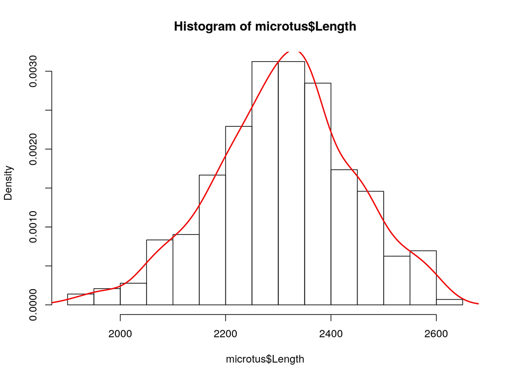

```r
# Plot a histogram with a nonparametric density estimate
hist(microtus$Length, freq = FALSE)
lines(density(microtus$Length), lwd = 2, col = "red2")
```

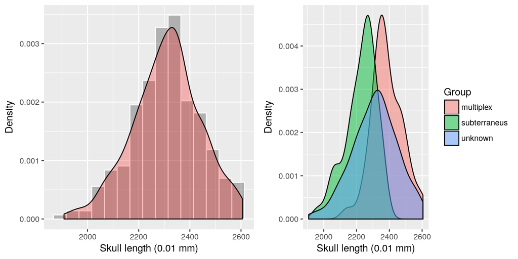

```r
# Plot a histogram and nonparametric density using ggplot2
p1 <- ggplot(microtus, aes(x = Length, y = ..density..)) +
  geom_histogram(bins = 15, color = "white", fill = "black", alpha = 0.25) +
  geom_density(alpha = 0.25, fill = "red") +
  xlab("Skull length (0.01 mm)") +
  ylab("Density")

# Plot a nonparametric density using ggplot2
p2 <- ggplot(microtus, aes(x = Length, fill = Group), color = "black") +
  geom_density(alpha = 0.5) +
  xlab("Skull length (0.01 mm)") +
  ylab("Density")

# Display both plots together
gridExtra::grid.arrange(p1, p2, ncol = 2)
```